# Travel Package Purchase Prediction

## Background and Context

"Visit with us" travel company wants to retain its customers for a longer time period by launching a long-term travel package. The company had launched a holiday package last year and 18% of the customers purchased that package however, the marketing cost was quite high because customers were contacted at random without looking at the available information.

Now again the company is planning to launch a new product i.e. a long term travel package, but this time company wants to utilize previously available data to reduce the marketing cost.

You as a data scientist at "Visit with us" travel company have to analyze the trend of existing customers' data and information to provide recommendations to the marketing team and also build a model to predict which customer is potentially going to purchase the long term travel package.

## Objective

- Explore and visualize the dataset.
- To predict which customers will purchase the long term travel package
- Which variables are most significant.
- Build Models using Bagging & Boosting to predict whether a person will take travel package or not
- Generate a set of insights and recommendations that will help the business to understand which segment of customers should be targeted more.

## Data Set

#### Customer details:

- CustomerID: Unique customer ID
- ProdTaken: Product taken flag
- Age: Age of customer
- PreferredLoginDevice: Preferred login device of the customer in last month
- CityTier: City tier
- Occupation: Occupation of customer
- Gender: Gender of customer
- NumberOfPersonVisited: Total number of person came with customer
- PreferredPropertyStar: Preferred hotel property rating by customer
- MaritalStatus: Marital status of customer
- NumberOfTrips: Average number of the trip in a year by customer
- Passport: Customer passport flag
- OwnCar: Customers owns a car flag
- NumberOfChildrenVisited: Total number of children visit with customer
- Designation: Designation of the customer in the current organization
- MonthlyIncome: Gross monthly income of the customer

### Customer interaction data:

- PitchSatisfactionScore: Sales pitch satisfactory score
- ProductPitched: Product pitched by a salesperson
- NumberOfFollowups: Total number of follow up has been done by sales person after sales pitch
- DurationOfPitch: Duration of the pitch by a salesman to customer

# Overview of the dataset

## Import necessary Libraries

```python
conda install -c conda-forge xgboost
#downloading XGBoost Classifier
```

[output not shown]

```python
 conda update -n base -c defaults conda
#downloading XGBoost Classifier
```

[output not shown]

```python
#downloading the libraries
import warnings
warnings.filterwarnings("ignore")

import numpy as np
import pandas as pd
import seaborn as sns
import matplotlib.pyplot as plt
from sklearn.tree import DecisionTreeClassifier
from sklearn.model_selection import GridSearchCV
from sklearn.ensemble import BaggingClassifier
from sklearn.ensemble import RandomForestClassifier
from sklearn.ensemble import AdaBoostClassifier, GradientBoostingClassifier,StackingClassifier
from xgboost import XGBClassifier
from sklearn import metrics
from sklearn.model_selection import GridSearchCV, train_test_split
```

```python
#Loading dataset
xls = pd.ExcelFile("Tourism.xlsx")
```

```python
print(xls.sheet_names)# printing the excel sheet names
```

```
['Data Dict', 'Tourism']
```

```python
tourism = pd.read_excel(xls, 'Tourism') # getting the data from Tourism sheet
```

```python
# copying data to another varaible to avoid any changes to original data
df=tourism.copy()
```

### Displaying the first 5 and last 5 rows in the dataset

```python
df.head()
```

|  | CustomerID | ProdTaken | Age | TypeofContact | CityTier | DurationOfPitch | Occupation | Gender | NumberOfPersonVisited | NumberOfFollowups | ProductPitched | PreferredPropertyStar | MaritalStatus | NumberOfTrips | Passport | PitchSatisfactionScore | OwnCar | NumberOfChildrenVisited | Designation | MonthlyIncome |
| --- | --- | --- | --- | --- | --- | --- | --- | --- | --- | --- | --- | --- | --- | --- | --- | --- | --- | --- | --- | --- |
| 0 | 200000 | 1 | 41.0 | Self Enquiry | 3 | 6.0 | Salaried | Female | 3 | 3.0 | Deluxe | 3.0 | Single | 1.0 | 1 | 2 | 1 | 0.0 | Manager | 20993.0 |
| 1 | 200001 | 0 | 49.0 | Company Invited | 1 | 14.0 | Salaried | Male | 3 | 4.0 | Deluxe | 4.0 | Divorced | 2.0 | 0 | 3 | 1 | 2.0 | Manager | 20130.0 |
| 2 | 200002 | 1 | 37.0 | Self Enquiry | 1 | 8.0 | Free Lancer | Male | 3 | 4.0 | Basic | 3.0 | Single | 7.0 | 1 | 3 | 0 | 0.0 | Executive | 17090.0 |
| 3 | 200003 | 0 | 33.0 | Company Invited | 1 | 9.0 | Salaried | Female | 2 | 3.0 | Basic | 3.0 | Divorced | 2.0 | 1 | 5 | 1 | 1.0 | Executive | 17909.0 |
| 4 | 200004 | 0 | NaN | Self Enquiry | 1 | 8.0 | Small Business | Male | 2 | 3.0 | Basic | 4.0 | Divorced | 1.0 | 0 | 5 | 1 | 0.0 | Executive | 18468.0 |

```python
df.tail()
```

|  | CustomerID | ProdTaken | Age | TypeofContact | CityTier | DurationOfPitch | Occupation | Gender | NumberOfPersonVisited | NumberOfFollowups | ProductPitched | PreferredPropertyStar | MaritalStatus | NumberOfTrips | Passport | PitchSatisfactionScore | OwnCar | NumberOfChildrenVisited | Designation | MonthlyIncome |
| --- | --- | --- | --- | --- | --- | --- | --- | --- | --- | --- | --- | --- | --- | --- | --- | --- | --- | --- | --- | --- |
| 4883 | 204883 | 1 | 49.0 | Self Enquiry | 3 | 9.0 | Small Business | Male | 3 | 5.0 | Deluxe | 4.0 | Unmarried | 2.0 | 1 | 1 | 1 | 1.0 | Manager | 26576.0 |
| 4884 | 204884 | 1 | 28.0 | Company Invited | 1 | 31.0 | Salaried | Male | 4 | 5.0 | Basic | 3.0 | Single | 3.0 | 1 | 3 | 1 | 2.0 | Executive | 21212.0 |
| 4885 | 204885 | 1 | 52.0 | Self Enquiry | 3 | 17.0 | Salaried | Female | 4 | 4.0 | Standard | 4.0 | Married | 7.0 | 0 | 1 | 1 | 3.0 | Senior Manager | 31820.0 |
| 4886 | 204886 | 1 | 19.0 | Self Enquiry | 3 | 16.0 | Small Business | Male | 3 | 4.0 | Basic | 3.0 | Single | 3.0 | 0 | 5 | 0 | 2.0 | Executive | 20289.0 |
| 4887 | 204887 | 1 | 36.0 | Self Enquiry | 1 | 14.0 | Salaried | Male | 4 | 4.0 | Basic | 4.0 | Unmarried | 3.0 | 1 | 3 | 1 | 2.0 | Executive | 24041.0 |

### Viewing the shape of data

```python
df.shape
```

```
(4888, 20)
```

This shows that there are 4888 rows and 20 columns.

### Checking the data types and columns of the dataset

```python
df.describe()
```

|  | CustomerID | ProdTaken | Age | CityTier | DurationOfPitch | NumberOfPersonVisited | NumberOfFollowups | PreferredPropertyStar | NumberOfTrips | Passport | PitchSatisfactionScore | OwnCar | NumberOfChildrenVisited | MonthlyIncome |
| --- | --- | --- | --- | --- | --- | --- | --- | --- | --- | --- | --- | --- | --- | --- |
| count | 4888.000000 | 4888.000000 | 4662.000000 | 4888.000000 | 4637.000000 | 4888.000000 | 4843.000000 | 4862.000000 | 4748.000000 | 4888.000000 | 4888.000000 | 4888.000000 | 4822.000000 | 4655.000000 |
| mean | 202443.500000 | 0.188216 | 37.622265 | 1.654255 | 15.490835 | 2.905074 | 3.708445 | 3.581037 | 3.236521 | 0.290917 | 3.078151 | 0.620295 | 1.187267 | 23619.853491 |
| std | 1411.188388 | 0.390925 | 9.316387 | 0.916583 | 8.519643 | 0.724891 | 1.002509 | 0.798009 | 1.849019 | 0.454232 | 1.365792 | 0.485363 | 0.857861 | 5380.698361 |
| min | 200000.000000 | 0.000000 | 18.000000 | 1.000000 | 5.000000 | 1.000000 | 1.000000 | 3.000000 | 1.000000 | 0.000000 | 1.000000 | 0.000000 | 0.000000 | 1000.000000 |
| 25% | 201221.750000 | 0.000000 | 31.000000 | 1.000000 | 9.000000 | 2.000000 | 3.000000 | 3.000000 | 2.000000 | 0.000000 | 2.000000 | 0.000000 | 1.000000 | 20346.000000 |
| 50% | 202443.500000 | 0.000000 | 36.000000 | 1.000000 | 13.000000 | 3.000000 | 4.000000 | 3.000000 | 3.000000 | 0.000000 | 3.000000 | 1.000000 | 1.000000 | 22347.000000 |
| 75% | 203665.250000 | 0.000000 | 44.000000 | 3.000000 | 20.000000 | 3.000000 | 4.000000 | 4.000000 | 4.000000 | 1.000000 | 4.000000 | 1.000000 | 2.000000 | 25571.000000 |
| max | 204887.000000 | 1.000000 | 61.000000 | 3.000000 | 127.000000 | 5.000000 | 6.000000 | 5.000000 | 22.000000 | 1.000000 | 5.000000 | 1.000000 | 3.000000 | 98678.000000 |

```python
df.corr()
```

|  | CustomerID | ProdTaken | Age | CityTier | DurationOfPitch | NumberOfPersonVisited | NumberOfFollowups | PreferredPropertyStar | NumberOfTrips | Passport | PitchSatisfactionScore | OwnCar | NumberOfChildrenVisited | MonthlyIncome |
| --- | --- | --- | --- | --- | --- | --- | --- | --- | --- | --- | --- | --- | --- | --- |
| CustomerID | 1.000000 | 0.056506 | 0.032127 | 0.012975 | 0.064298 | 0.604013 | 0.427539 | 0.010553 | 0.224848 | 0.007974 | -0.035847 | 0.003805 | 0.511763 | 0.276833 |
| ProdTaken | 0.056506 | 1.000000 | -0.147254 | 0.086852 | 0.078257 | 0.009627 | 0.112171 | 0.099577 | 0.018898 | 0.260844 | 0.051394 | -0.011508 | 0.007421 | -0.130585 |
| Age | 0.032127 | -0.147254 | 1.000000 | -0.015625 | -0.012063 | 0.011621 | -0.002577 | -0.010474 | 0.184905 | 0.033399 | 0.018510 | 0.048654 | 0.007370 | 0.464869 |
| CityTier | 0.012975 | 0.086852 | -0.015625 | 1.000000 | 0.022703 | -0.001671 | 0.023652 | -0.009164 | -0.029709 | 0.001793 | -0.042160 | 0.003817 | 0.000672 | 0.051817 |
| DurationOfPitch | 0.064298 | 0.078257 | -0.012063 | 0.022703 | 1.000000 | 0.065141 | 0.009434 | -0.006637 | 0.009715 | 0.033034 | -0.002880 | -0.001626 | 0.031408 | -0.006252 |
| NumberOfPersonVisited | 0.604013 | 0.009627 | 0.011621 | -0.001671 | 0.065141 | 1.000000 | 0.328569 | 0.033867 | 0.195223 | 0.011177 | -0.019581 | 0.010362 | 0.610621 | 0.195134 |
| NumberOfFollowups | 0.427539 | 0.112171 | -0.002577 | 0.023652 | 0.009434 | 0.328569 | 1.000000 | -0.024176 | 0.139517 | 0.004970 | 0.004054 | 0.012112 | 0.286425 | 0.176503 |
| PreferredPropertyStar | 0.010553 | 0.099577 | -0.010474 | -0.009164 | -0.006637 | 0.033867 | -0.024176 | 1.000000 | 0.012115 | 0.001040 | -0.022701 | 0.015742 | 0.035798 | 0.014289 |
| NumberOfTrips | 0.224848 | 0.018898 | 0.184905 | -0.029709 | 0.009715 | 0.195223 | 0.139517 | 0.012115 | 1.000000 | 0.012949 | -0.004378 | -0.011825 | 0.168795 | 0.139105 |
| Passport | 0.007974 | 0.260844 | 0.033399 | 0.001793 | 0.033034 | 0.011177 | 0.004970 | 0.001040 | 0.012949 | 1.000000 | 0.002926 | -0.022330 | 0.020264 | 0.002545 |
| PitchSatisfactionScore | -0.035847 | 0.051394 | 0.018510 | -0.042160 | -0.002880 | -0.019581 | 0.004054 | -0.022701 | -0.004378 | 0.002926 | 1.000000 | 0.068850 | 0.000878 | 0.030421 |
| OwnCar | 0.003805 | -0.011508 | 0.048654 | 0.003817 | -0.001626 | 0.010362 | 0.012112 | 0.015742 | -0.011825 | -0.022330 | 0.068850 | 1.000000 | 0.026572 | 0.080262 |
| NumberOfChildrenVisited | 0.511763 | 0.007421 | 0.007370 | 0.000672 | 0.031408 | 0.610621 | 0.286425 | 0.035798 | 0.168795 | 0.020264 | 0.000878 | 0.026572 | 1.000000 | 0.201643 |
| MonthlyIncome | 0.276833 | -0.130585 | 0.464869 | 0.051817 | -0.006252 | 0.195134 | 0.176503 | 0.014289 | 0.139105 | 0.002545 | 0.030421 | 0.080262 | 0.201643 | 1.000000 |

```python
df.info()
```

```
<class 'pandas.core.frame.DataFrame'>
RangeIndex: 4888 entries, 0 to 4887
Data columns (total 20 columns):
 #   Column                   Non-Null Count  Dtype
---  ------                   --------------  -----
 0   CustomerID               4888 non-null   int64
 1   ProdTaken                4888 non-null   int64
 2   Age                      4662 non-null   float64
 3   TypeofContact            4863 non-null   object
 4   CityTier                 4888 non-null   int64
 5   DurationOfPitch          4637 non-null   float64
 6   Occupation               4888 non-null   object
 7   Gender                   4888 non-null   object
 8   NumberOfPersonVisited    4888 non-null   int64
 9   NumberOfFollowups        4843 non-null   float64
 10  ProductPitched           4888 non-null   object
 11  PreferredPropertyStar    4862 non-null   float64
 12  MaritalStatus            4888 non-null   object
 13  NumberOfTrips            4748 non-null   float64
 14  Passport                 4888 non-null   int64
 15  PitchSatisfactionScore   4888 non-null   int64
 16  OwnCar                   4888 non-null   int64
 17  NumberOfChildrenVisited  4822 non-null   float64
 18  Designation              4888 non-null   object
 19  MonthlyIncome            4655 non-null   float64
dtypes: float64(7), int64(7), object(6)
memory usage: 763.9+ KB
```

```python
df.isnull().any()
```

```
CustomerID                 False
ProdTaken                  False
Age                         True
TypeofContact               True
CityTier                   False
DurationOfPitch             True
Occupation                 False
Gender                     False
NumberOfPersonVisited      False
NumberOfFollowups           True
ProductPitched             False
PreferredPropertyStar       True
MaritalStatus              False
NumberOfTrips               True
Passport                   False
PitchSatisfactionScore     False
OwnCar                     False
NumberOfChildrenVisited     True
Designation                False
MonthlyIncome               True
dtype: bool
```

#### Observation

- The columns: Age, NumberofTrips, NumberofChildrenVisited are of the float data type, which we can convert to categorical variables (NumberofChildrenVisited only)
- It is obvious that there is presence of missing values in the dataset

### Adjusting the column types int the dataset

```python
#selecting columns with datatype as object
cols = df.select_dtypes(['object'])
cols.columns
```

```
Index(['TypeofContact', 'Occupation', 'Gender', 'ProductPitched',
       'MaritalStatus', 'Designation'],
      dtype='object')
```

```python
#Converting object to category datatype
for i in cols.columns:
    df[i] = df[i].astype('category')
```

```python
cols_to_convert = df[['ProdTaken','CityTier','NumberOfPersonVisited','NumberOfFollowups','PreferredPropertyStar','NumberOfTrips','Passport','PitchSatisfactionScore','OwnCar','NumberOfChildrenVisited']]
cols_to_convert.columns
```

```
Index(['ProdTaken', 'CityTier', 'NumberOfPersonVisited', 'NumberOfFollowups',
       'PreferredPropertyStar', 'NumberOfTrips', 'Passport',
       'PitchSatisfactionScore', 'OwnCar', 'NumberOfChildrenVisited'],
      dtype='object')
```

```python
for i in cols_to_convert.columns:
    df[i] = df[i].astype('category')
```

```python
df.info()
#to see if changes have been made in the dataset
```

```
<class 'pandas.core.frame.DataFrame'>
RangeIndex: 4888 entries, 0 to 4887
Data columns (total 20 columns):
 #   Column                   Non-Null Count  Dtype
---  ------                   --------------  -----
 0   CustomerID               4888 non-null   int64
 1   ProdTaken                4888 non-null   category
 2   Age                      4662 non-null   float64
 3   TypeofContact            4863 non-null   category
 4   CityTier                 4888 non-null   category
 5   DurationOfPitch          4637 non-null   float64
 6   Occupation               4888 non-null   category
 7   Gender                   4888 non-null   category
 8   NumberOfPersonVisited    4888 non-null   category
 9   NumberOfFollowups        4843 non-null   category
 10  ProductPitched           4888 non-null   category
 11  PreferredPropertyStar    4862 non-null   category
 12  MaritalStatus            4888 non-null   category
 13  NumberOfTrips            4748 non-null   category
 14  Passport                 4888 non-null   category
 15  PitchSatisfactionScore   4888 non-null   category
 16  OwnCar                   4888 non-null   category
 17  NumberOfChildrenVisited  4822 non-null   category
 18  Designation              4888 non-null   category
 19  MonthlyIncome            4655 non-null   float64
dtypes: category(16), float64(3), int64(1)
memory usage: 231.9 KB
```

### Rechecking the summary of the dataset

```python
df.describe()
```

|  | CustomerID | Age | DurationOfPitch | MonthlyIncome |
| --- | --- | --- | --- | --- |
| count | 4888.000000 | 4662.000000 | 4637.000000 | 4655.000000 |
| mean | 202443.500000 | 37.622265 | 15.490835 | 23619.853491 |
| std | 1411.188388 | 9.316387 | 8.519643 | 5380.698361 |
| min | 200000.000000 | 18.000000 | 5.000000 | 1000.000000 |
| 25% | 201221.750000 | 31.000000 | 9.000000 | 20346.000000 |
| 50% | 202443.500000 | 36.000000 | 13.000000 | 22347.000000 |
| 75% | 203665.250000 | 44.000000 | 20.000000 | 25571.000000 |
| max | 204887.000000 | 61.000000 | 127.000000 | 98678.000000 |

```python
df.describe().T #checking the transpose
```

|  | count | mean | std | min | 25% | 50% | 75% | max |
| --- | --- | --- | --- | --- | --- | --- | --- | --- |
| CustomerID | 4888.0 | 202443.500000 | 1411.188388 | 200000.0 | 201221.75 | 202443.5 | 203665.25 | 204887.0 |
| Age | 4662.0 | 37.622265 | 9.316387 | 18.0 | 31.00 | 36.0 | 44.00 | 61.0 |
| DurationOfPitch | 4637.0 | 15.490835 | 8.519643 | 5.0 | 9.00 | 13.0 | 20.00 | 127.0 |
| MonthlyIncome | 4655.0 | 23619.853491 | 5380.698361 | 1000.0 | 20346.00 | 22347.0 | 25571.00 | 98678.0 |

```python
df.describe(include=['category']).T
```

|  | count | unique | top | freq |
| --- | --- | --- | --- | --- |
| ProdTaken | 4888 | 2 | 0 | 3968 |
| TypeofContact | 4863 | 2 | Self Enquiry | 3444 |
| CityTier | 4888 | 3 | 1 | 3190 |
| Occupation | 4888 | 4 | Salaried | 2368 |
| Gender | 4888 | 3 | Male | 2916 |
| NumberOfPersonVisited | 4888 | 5 | 3 | 2402 |
| NumberOfFollowups | 4843 | 6 | 4 | 2068 |
| ProductPitched | 4888 | 5 | Basic | 1842 |
| PreferredPropertyStar | 4862 | 3 | 3 | 2993 |
| MaritalStatus | 4888 | 4 | Married | 2340 |
| NumberOfTrips | 4748 | 12 | 2 | 1464 |
| Passport | 4888 | 2 | 0 | 3466 |
| PitchSatisfactionScore | 4888 | 5 | 3 | 1478 |
| OwnCar | 4888 | 2 | 1 | 3032 |
| NumberOfChildrenVisited | 4822 | 4 | 1 | 2080 |
| Designation | 4888 | 5 | Executive | 1842 |

```python
#drop the customer id column because it is not really needed.
df.drop(['CustomerID'],axis=1,inplace=True)
```

### Checking for presence of unique values in the variables

```python
cols_cat= df.select_dtypes(['category'])
```

```python
for i in cols_cat.columns:
    print('Unique values in',i, 'are :')
    print(cols_cat[i].value_counts())
    print('*'*50)
```

```
Unique values in ProdTaken are :
0    3968
1     920
Name: ProdTaken, dtype: int64
Unique values in TypeofContact are :
Self Enquiry       3444
Company Invited    1419
Name: TypeofContact, dtype: int64
Unique values in CityTier are :
1    3190
3    1500
2     198
Name: CityTier, dtype: int64
Unique values in Occupation are :
Salaried          2368
Small Business    2084
Large Business     434
Free Lancer          2
Name: Occupation, dtype: int64
Unique values in Gender are :
Male       2916
Female     1817
Fe Male     155
Name: Gender, dtype: int64
Unique values in NumberOfPersonVisited are :
3    2402
2    1418
4    1026
1      39
5       3
Name: NumberOfPersonVisited, dtype: int64
Unique values in NumberOfFollowups are :
4.0    2068
3.0    1466
5.0     768
2.0     229
1.0     176
6.0     136
Name: NumberOfFollowups, dtype: int64
Unique values in ProductPitched are :
```

[output cut: 44 more lines]

```
0    1856
Name: OwnCar, dtype: int64
Unique values in NumberOfChildrenVisited are :
1.0    2080
2.0    1335
0.0    1082
3.0     325
Name: NumberOfChildrenVisited, dtype: int64
Unique values in Designation are :
Executive         1842
Manager           1732
Senior Manager     742
AVP                342
VP                 230
Name: Designation, dtype: int64
```

#### Observation:

- There are unique values in the datset
- There are more customers which are Male and salaried occupation
- There is very low number of trip values for the younger ages
- In the gender category this might be an error so i would suggest combining the Fe Male with the Female category

### Converting the "Fe Male" with the "Female" category

```python
df['Gender'] = df['Gender'].apply(lambda x: 'Female' if x == 'Fe Male' else x)
```

```python
df['Gender'].value_counts()
#viewing to see if changes have been made
```

```
Male      2916
Female    1972
Name: Gender, dtype: int64
```

# Exploratory Data Analysis (EDA)

## Univariate Analysis

```python
# to make it easier and faster analysis of the numerical variables
# I will create a function that will create a histogram and boxplot together for the numerical variables

def histogram_boxplot(feature, figsize=(15,10), bins = None):
    """ Boxplot and histogram combined
    feature: 1-d feature array
    figsize: size of fig (default (9,8))
    bins: number of bins (default None / auto)
    """
    f2, (ax_box2, ax_hist2) = plt.subplots(nrows = 2, # Number of rows of the subplot grid= 2
                                           sharex = True, # x-axis will be shared among all subplots
                                           gridspec_kw = {"height_ratios": (.25, .75)},
                                           figsize = figsize
                                           ) # creating the 2 subplots
    sns.boxplot(feature, ax=ax_box2, showmeans=True, color='violet') # boxplot will be created and a star will indicate the mean value of the column
    sns.distplot(feature, kde=F, ax=ax_hist2, bins=bins,palette="spring") if bins else sns.distplot(feature, kde=False, ax=ax_hist2) # For histogram
    ax_hist2.axvline(np.mean(feature), color='yellow', linestyle='--') # Add mean to the histogram
    ax_hist2.axvline(np.median(feature), color='red', linestyle='-') # Add median to the histogram
```

## Age

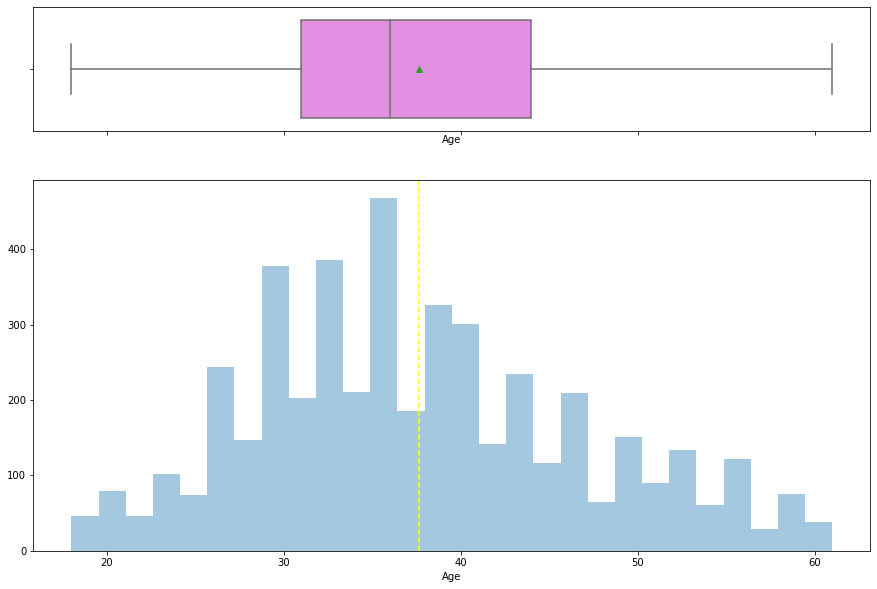

```python
histogram_boxplot(df['Age'])
```

From the above graph it reveals that Age is normally distributed and most of the customers age is greater than 30

## DurationOfPitch

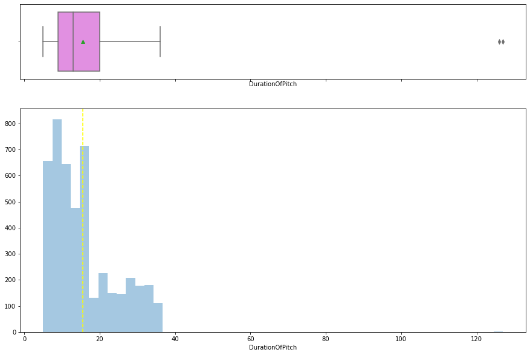

```python
histogram_boxplot(df['DurationOfPitch'])
```

## Monthly Income

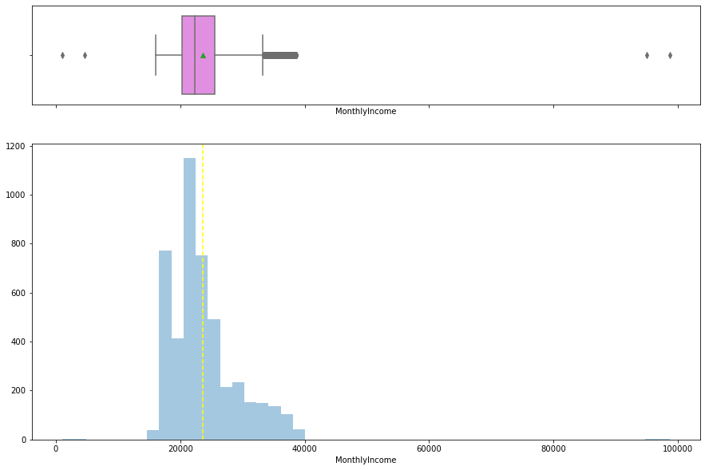

```python
histogram_boxplot(df['MonthlyIncome'])
```

This shows that most of the customers are earning 20k to 30k, where as 10% of the customers are earning around 40k per month. This also shows that there a few outliers representing very few high and low income.

## ProdTaken

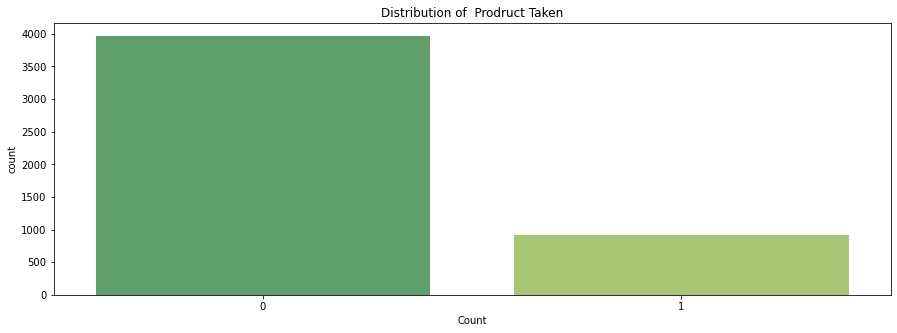

```python
plt.figure(figsize=(15,5))
ax = sns.countplot(df["ProdTaken"],palette='summer')
plt.title('Distribution of  Prodruct Taken')
plt.xlabel('Count')

plt.show()
```

- 18.8% of the records have acquired the holiday package
- However the other 80% of customers did not opt for any travel package.

## Type of Contact

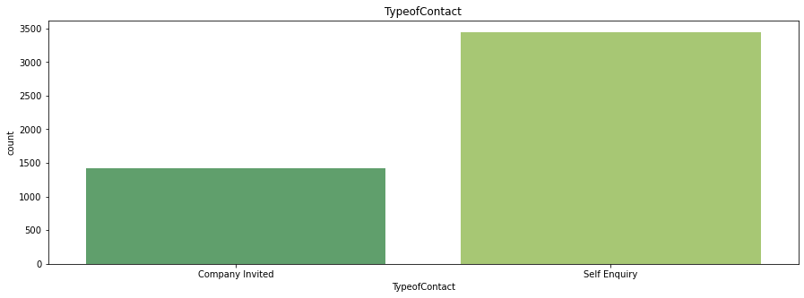

```python
plt.figure(figsize=(15,5))
ax = sns.countplot(df["TypeofContact"],palette='summer')
plt.title('TypeofContact')
```

- About 70% of the customers have reached the company through "Self-Enquiry"
- While the other 30% of customers have known the company through "Company Invites"

## City Tier

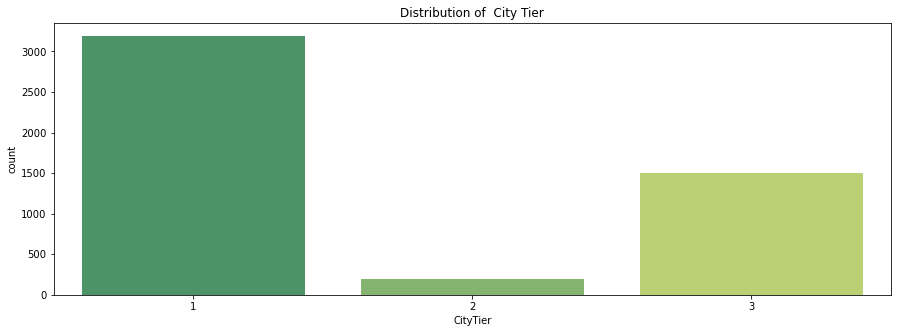

```python
plt.figure(figsize=(15,5))
ax = sns.countplot(df["CityTier"],palette='summer')
plt.title('Distribution of  City Tier')
total = len(df['CityTier'])
```

- 65% of the customers are from Tier-1 cities and 30% of the customers from Tier 3 cities.

## Occupation

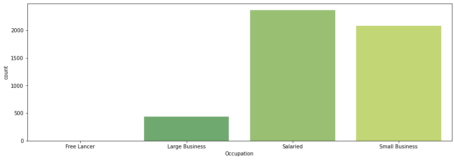

```python
plt.figure(figsize=(15,5))
sns.countplot(df["Occupation"],palette='summer')
```

- Almost up to half of the customers are salaried
- While the other customers are either running large or small businesses
- This can also that there is presence of outliers for Free Lancer

## Gender

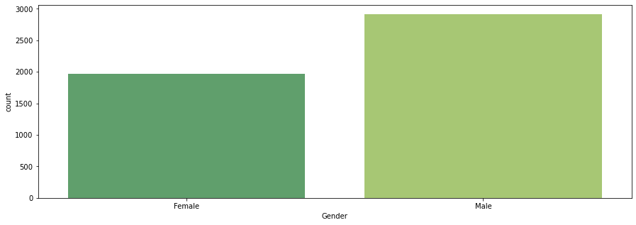

```python
plt.figure(figsize=(15,5))
ax = sns.countplot(df["Gender"],palette='summer')
```

- 60% of the customers are Male and rest of the 40% are female

## Number of Person Visited

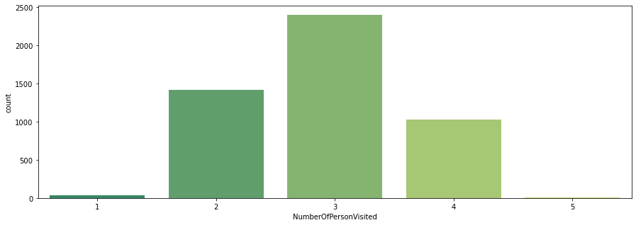

```python
plt.figure(figsize=(15,5))
ax = sns.countplot(df["NumberOfPersonVisited"],palette='summer')
```

- Most of the times 3 to 2 persons visited
- only 21% of the times 4 persons visited

## Preferred Property Star

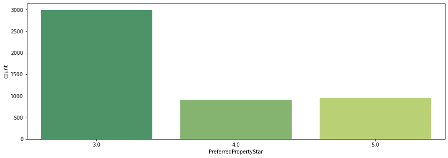

```python
plt.figure(figsize=(15,5))
ax = sns.countplot(df["PreferredPropertyStar"],palette='summer')
```

## Marital Status

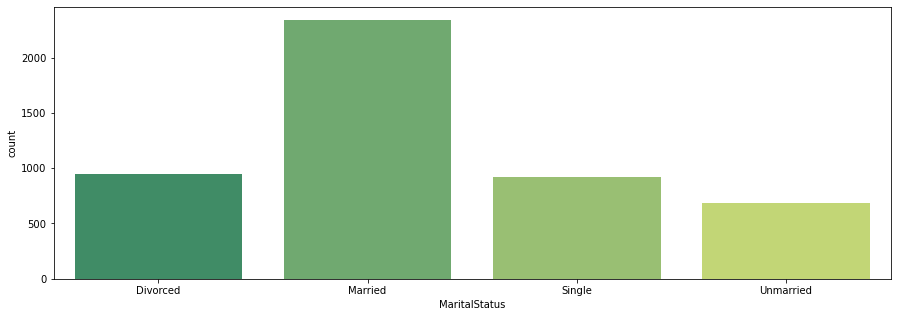

```python
plt.figure(figsize=(15,5))
ax = sns.countplot(df["MaritalStatus"],palette='summer')
```

- Majority of the customers are married followed
- 38% of the customers are Divorced/Single
- While only 14% of the customers are Unmarried

## Number of Trips

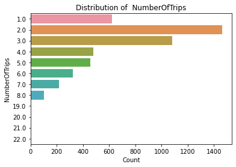

```python
ax = sns.countplot(y="NumberOfTrips", data=df)
plt.title('Distribution of  NumberOfTrips')
plt.xlabel('Count')
```

- Most of the customers take 2 trips per year
- 52% of the customers have made 2 to 3 trips and there are 6% of the customers who made 7 to 8 trips

## Passport

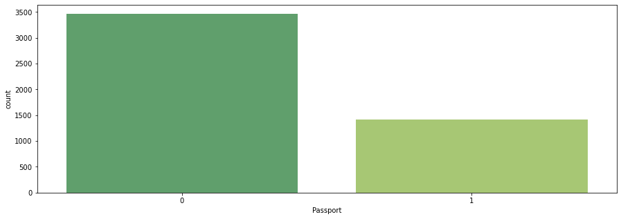

```python
plt.figure(figsize=(15,5))
ax = sns.countplot(df["Passport"],palette='summer')
```

- Majority of the customers do not own passport

## Own Car

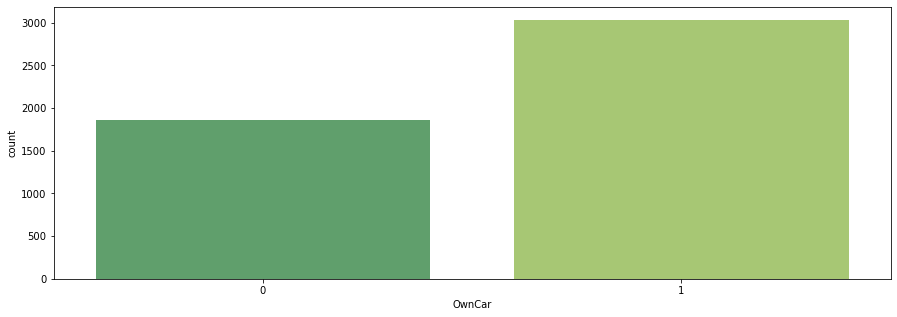

```python
plt.figure(figsize=(15,5))
ax = sns.countplot(df["OwnCar"],palette='summer')
```

- Most of the customers are owners of a car

## Number Of Children Visited

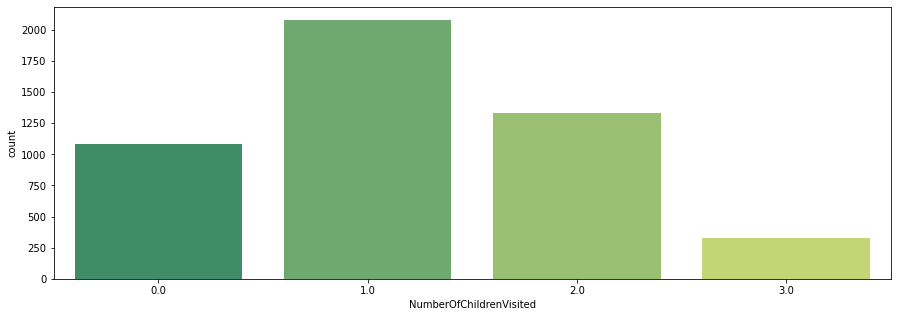

```python
plt.figure(figsize=(15,5))
ax = sns.countplot(df["NumberOfChildrenVisited"],palette='summer')
```

- Most of the customers had only one child visit with them

## Designation

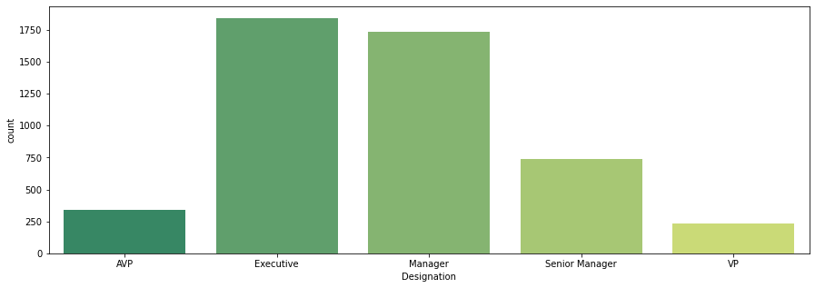

```python
plt.figure(figsize=(15,5))
ax = sns.countplot(df["Designation"],palette='summer')
```

- Most of the customers at Manager/Executive level in their occupation and rest of the customers at higher positions

## Pitch Satisfaction Score

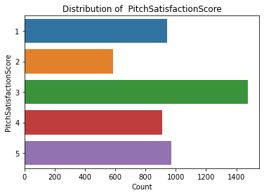

```python
ax = sns.countplot(y="PitchSatisfactionScore", data=df)
plt.title('Distribution of  PitchSatisfactionScore')
plt.xlabel('Count')
```

- Most of the Pitch Satisfaction score indicate a score of 3

## Number of Followups

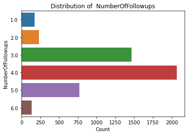

```python
ax = sns.countplot(y="NumberOfFollowups", data=df)
plt.title('Distribution of  NumberOfFollowups')
plt.xlabel('Count')
```

- 4 has been the most number of followups made having percentage of 42.3%

## Product Pitched

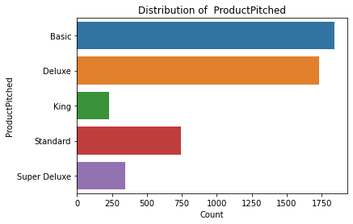

```python
ax = sns.countplot(y="ProductPitched", data=df)
plt.title('Distribution of  ProductPitched')
plt.xlabel('Count')
```

- Basic and Deluxe products were pitched most of the times

# Multivariate Analysis

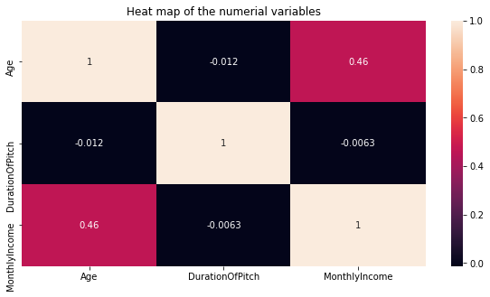

```python
# heat map of the numerial variables
plt.figure(figsize=(10,5))
sns.heatmap(df.corr(),annot=True)
plt.title('Heat map of the numerial variables')
plt.show()
```

The heatmap reveals that Age and MonthlyIncome are correlated which is makes sense.

[figure not shown]

```python
sns.pairplot(df,hue='ProdTaken')
plt.show()
```

## Bivariate Analysis of ProdTaken with continuous variables

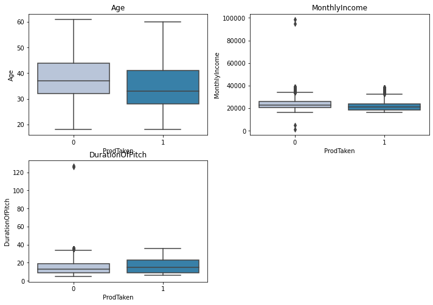

```python
cols = df[['Age','MonthlyIncome','DurationOfPitch']].columns.tolist()
plt.figure(figsize=(10,10))

for i, variable in enumerate(cols):
                     plt.subplot(3,2,i+1)
                     sns.boxplot(df["ProdTaken"],df[variable],palette="PuBu")
                     plt.tight_layout()
                     plt.title(variable)
plt.show()
```

#### Observations

- There is not much difference in the monthly income of customers who have and have not taken the package
- The holiday package has been taken mostly by customers who are of less than 40 years of age
- The that package has been taken when thers is higher duration of pitch by salesman to the customer